# AlyssaHusna(52213223155)_IndividualAssignment

**Individual Assignment: Dataset Analysis using K-Means Clustering**

**Student Details**

- Name: **Alyssa Husna binti Jamarizan**
- Student ID: **52213223155**
- Lab Group: **L01-B02**
- Link: https://github.com/alys-source14/PCOI_IndividualAssignment.git

## 1. Load and Explore Data (5 points)

### 1.1 Import libraries and load dataset.

#### Import the necessary libraries

```python
import numpy as np                               # NumPy: Used for numerical operations and handling arrays/matrices
import pandas as pd                              # Pandas: Used for data manipulation and analysis with DataFrames
import seaborn as sns                            # Seaborn: A data visualization library based on Matplotlib, useful for statistical plots
import matplotlib.pyplot as plt                  # Matplotlib: A plotting library for creating visualizations like graphs, charts, etc.
from sklearn import preprocessing                # Sklearn's preprocessing module: Provides utilities for scaling and transforming data
from sklearn.preprocessing import MinMaxScaler   # MinMaxScaler: A method to scale data within a fixed range (typically 0 to 1)
from sklearn.cluster import KMeans               # KMeans: A clustering algorithm used to partition data into clusters
from sklearn.metrics import silhouette_score     # Silhouette Score: A metric to evaluate the quality of clustering
```

#### Load dataset using Python

```python
customer_data = pd.read_csv('customers.csv', usecols=['Age', 'Annual Income (k$)', 'Spending Score (1-100)'])
```

### 1.2 Explore dataset briefly to understand its structure.

#### Understand the Structure of the Dataset

##### Display first 5 rows to get an idea of the dataset

```python
customer_data.head()
```

|  | Age | Annual Income (k$) | Spending Score (1-100) |
| --- | --- | --- | --- |
| 0 | 19 | 15 | 39 |
| 1 | 21 | 15 | 81 |
| 2 | 20 | 16 | 6 |
| 3 | 23 | 16 | 77 |
| 4 | 31 | 17 | 40 |

##### Display info on data types (data types, non-null counts, and column names) & missing values

```python
customer_data.info()
print("\n")
customer_data.isnull().sum()
```

```
<class 'pandas.core.frame.DataFrame'>
RangeIndex: 200 entries, 0 to 199
Data columns (total 3 columns):
 #   Column                  Non-Null Count  Dtype
---  ------                  --------------  -----
 0   Age                     200 non-null    int64
 1   Annual Income (k$)      200 non-null    int64
 2   Spending Score (1-100)  200 non-null    int64
dtypes: int64(3)
memory usage: 4.8 KB
```

```
Age                       0
Annual Income (k$)        0
Spending Score (1-100)    0
dtype: int64
```

##### Display summary statistics as in a summary (mean, min, max, etc.) for Age and Spending Score.

```python
customer_data.describe()
```

|  | Age | Annual Income (k$) | Spending Score (1-100) |
| --- | --- | --- | --- |
| count | 200.000000 | 200.000000 | 200.000000 |
| mean | 38.850000 | 60.560000 | 50.200000 |
| std | 13.969007 | 26.264721 | 25.823522 |
| min | 18.000000 | 15.000000 | 1.000000 |
| 25% | 28.750000 | 41.500000 | 34.750000 |
| 50% | 36.000000 | 61.500000 | 50.000000 |
| 75% | 49.000000 | 78.000000 | 73.000000 |
| max | 70.000000 | 137.000000 | 99.000000 |

#### Visualise Data Distribution

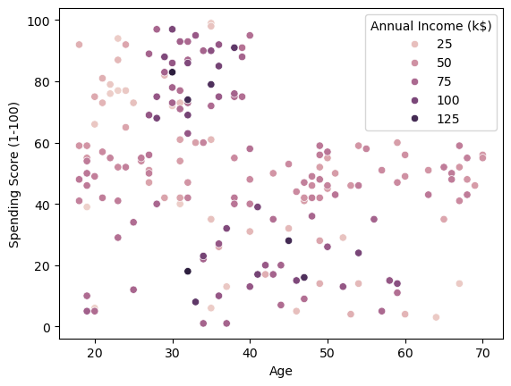

```python
sns.scatterplot(data = customer_data, x = 'Age', y = 'Spending Score (1-100)', hue = 'Annual Income (k$)')
plt.show()
```

## 2. Data Preprocessing (5 points)

### 2.1 Standardise (in this case *Normalise*) dataset if necessary to ensure all features have similar scale.

- **Data Normalisation** is needed here to ensure all features (Age, Annual Income, and Spending Score) are on a similar scale. This prevents features with larger ranges from dominating the clustering process.
- Min-Max Scaling normalises features to a specified range (in this case 1 to 100). This keeps the relative differences between features while keeping their values interpretable within original context.
- Although Data Standardization (scaling features to a mean of 0 and standard deviation of 1) is commonly used for K-Means, Data Normalisation is equally valid and is being applied here to avoid distorting the data's interpretability for Age and Spending Score.

In lab 5, we were taught about **Dataset Splitting**:

- However, Dataset Splitting is typically done for *supervised learning*, where we test the model's predictions on unseen data. For this k-clustering is *unsupervised*, this step is unnecessary here.
- While Standardization is often recommended for K-Means, Min-Max Scaling can also be applied effectively to preserve interpretability. This ensures features like Age (1-70) and Spending Score (1-100) remain intuitive after scaling.

#### Apply Min-Max Scaling

```python
scaler = MinMaxScaler(feature_range=(1, 100))  # Keeping values interpretable within 1–100
customer_data_scaled = scaler.fit_transform(customer_data[['Age', 'Spending Score (1-100)', 'Annual Income (k$)']])
```

#### Convert Convert scaled data to a DataFrame for checking

```python
customer_data_scaled_df = pd.DataFrame(customer_data_scaled, columns=['Age', 'Spending Score (1-100)', 'Annual Income (k$)'])
```

#### Check the normalised dataset

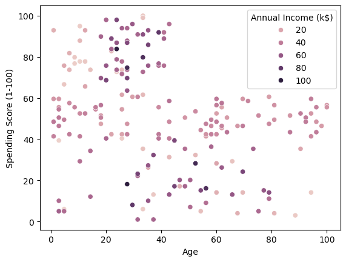

```python
customer_data_scaled_df.describe()
sns.scatterplot(data = customer_data_scaled_df, x = 'Age', y = 'Spending Score (1-100)', hue = 'Annual Income (k$)')
plt.show()
```

## 3. K-Means Clustering (15 points)

### 3.1 Choosing appropriate value for K based on analysis and justify.

To determine optimal value of K, two methods were used:

1. Elbow Method: analyse the inertia (sum of squared distances to cluster centers)
2. Silhouette Score: check how well each data point fits within its cluster

Both methods will be visualized, and the results compared to select the best value for K.

#### 3.1.1 Elbow Method

- A technique used to **identify the optimal number of clusters (K) for K-Means clustering by looking at the inertia**.
- Inertia is the sum of squared distances of each data point to its assigned cluster center. The idea is that as K increases, inertia decreases.
- However, there’s a point where inertia starts to decrease at a much slower rate, which is the *elbow* point. This is where adding more clusters does not significantly improve the clustering.
- This method helps identify the best balance between underfitting(*K is too small, leading to overly simplistic models that fail to capture underlying patterns in the data.*) and overfitting(*K is too large, creating too many clusters, some of which may be unnecessary or not meaningful.*).

**TL;DR The elbow point on the curve (*the point before the bent part*) indicates optimal K, where adding another cluster does'nt significantly reduce inertia. This method helps in finding the best balance between underfitting and overfitting.**

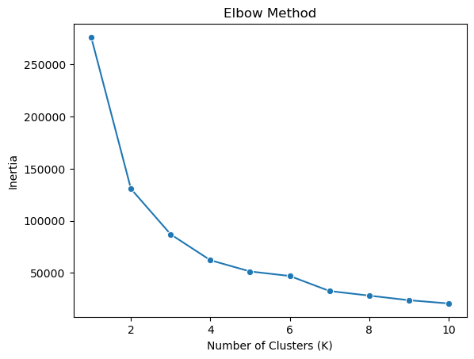

```python
# Elbow method for optimal K
inertia = []
k_range = range(1, 11)  # Trying values from 1 to 10 for K
for k in k_range:
    kmeans = KMeans(n_clusters=k, random_state=50)
    kmeans.fit(customer_data_scaled_df[['Age', 'Spending Score (1-100)']])  # Using only Age and Spending Score
    inertia.append(kmeans.inertia_)

# Plot graph
sns.lineplot(x=k_range, y=inertia, marker='o')
plt.title("Elbow Method")
plt.xlabel("Number of Clusters (K)")
plt.ylabel("Inertia")
plt.show()
```

Explaination:

- In this dataset, the elbow method did not show a clear bend, and inertia kept decreasing without a distinct elbow.
- This suggests that the dataset may not have well-separated clusters, or the data might not align well with K-Means assumptions.

#### 3.1.2 Silhouette Score

- The score ranges from -1 to 1, where a score closer to 1 indicates well-separated clusters.
- It can only be computed for K values > 1, as K=1 doesn’t make sense in terms of measuring separation between clusters. So the range will be a bit different from earlier when using elbow method.
- It measures how similar each point is to its own cluster compared to other clusters, basically evaluates quality of clustering.
- A higher silhouette score means better-defined clusters and optimal K maximizes this sco.

**TL;DR The silhouette score measures how similar each point is to its own cluster compared to others. Higher score shows better-defined clusters. The optimal K is one with highest score.**

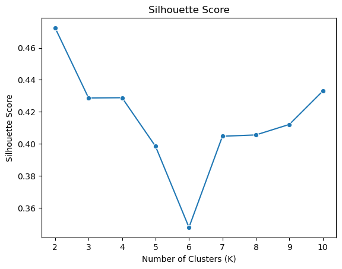

```python
# Silhouette Score to determine the optimal number of clusters
silhouette_scores = []
k_range = range(2, 11)
for k in k_range:
    kmeans = KMeans(n_clusters=k, random_state=50)
    kmeans.fit(customer_data_scaled_df[['Age', 'Spending Score (1-100)']])
    score = silhouette_score(customer_data_scaled_df[['Age', 'Spending Score (1-100)']], kmeans.labels_)
    silhouette_scores.append(score)

# Plot Scores
sns.lineplot(x=k_range, y=silhouette_scores, marker='o')
plt.title("Silhouette Score")
plt.xlabel("Number of Clusters (K)")
plt.ylabel("Silhouette Score")
plt.show()
```

Explaination:

- The silhouette score analysis suggests that the best clustering is achieved with K=2, as this value provides the highest silhouette score, indicating that the two clusters are well-separated and cohesive.
- This indicates that the dataset has a natural division into two distinct groups based on age and spending score.

### Selecting the Optimal K

In my analysis, I first used the **elbow method** to determine the optimal number of clusters. However, the **inertia continued to decrease smoothly without a clear bend**, suggesting that the elbow method was **not conclusive** in this case.

Then I used the **silhouette score** to determine the optimal K. The silhouette score analysis showed that the **number of clusters peaked at K=2**, which **indicates the best cohesion and separation between clusters**.

Based on this analysis, the data seems to naturally separate into two distinct groups. Therefore, ***K=2 is chosen as the optimal number of clusters***, as it maximizes the silhouette score and provides the best separation of customer segments.

## 3.2 Implement the K-Means clustering algorithm using the KMeans class from Scikit-Learn.

#### Implementing K-Means Clustering with the chosen K

```python
# Implement K-Means with optimal K
kmeans = KMeans(n_clusters=2, random_state=50)
customer_data_scaled_df['Cluster'] = kmeans.fit_predict(customer_data_scaled_df[['Age', 'Spending Score (1-100)']])
```

## 4. Cluster Visualisation (10 points)

### Visualise the clusters in a 2D scatter plot.

The two different clusters are indicated with distinct colours using seaborn palette.

#### Cluster visualisation

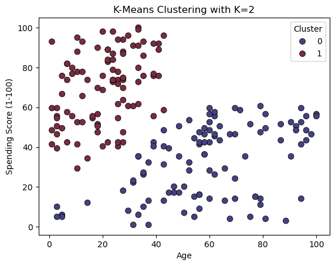

```python
sns.scatterplot(data=customer_data_scaled_df, x='Age', y='Spending Score (1-100)', hue='Cluster', palette='icefire', s= 50, edgecolor='black')
plt.title('K-Means Clustering with K=2')
plt.xlabel('Age')
plt.ylabel('Spending Score (1-100)')
plt.legend(title='Cluster')
plt.show()
```

#### Centroid visualization

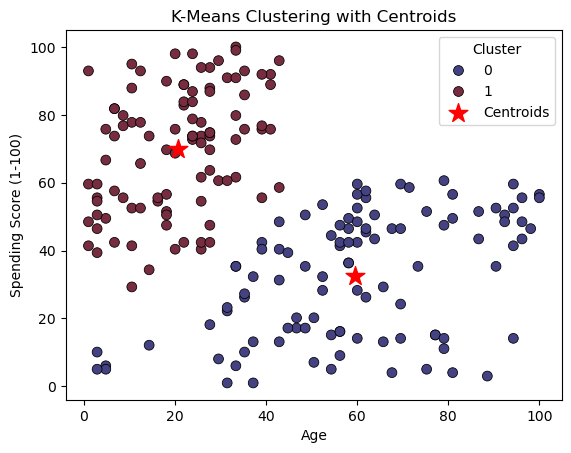

```python
centroids = kmeans.cluster_centers_
sns.scatterplot(data=customer_data_scaled_df, x='Age', y='Spending Score (1-100)', hue='Cluster', palette='icefire', s=50, edgecolor='black')
plt.scatter(centroids[:, 0], centroids[:, 1], s=200, c='red', marker='*', label='Centroids')
plt.title('K-Means Clustering with Centroids')
plt.xlabel('Age')
plt.ylabel('Spending Score (1-100)')
plt.legend(title='Cluster')
plt.show()
```

## 5. Cluster Analysis (5 points)

### Analyse results

#### 5.1 Characteristics of each cluster

[output not shown]

### Discuss cluster characteristics, and provide insights

#### 5.2 Insights on Clustering

##### 5.2.2 What about the outliers

**Cluster 0 Outliers**:

1. *High-Spending, Older Customers*: Outliers in this cluster could represent older cutomers who are still actively spending. They may have higher disposable incomes due to retirement savings, inheritance, or continued employment.
2. *Low-Spending, Younger Customers*: Outliers on the lower end of the spending spectrum might be younger customers who prioritize saving over spending, perhaps due to student loans, or their personal financial goals.

**Cluster 1 Outliers**:

1. *High-Spending, Older Customers*: Outliers in this cluster could represent older customers who are still actively spending, possibly due to increased leisure time, health concerns, or a desire to maintain a certain lifestyle.
2. *Low-Spending, Younger Customers*: Outliers on the lower end of the spending spectrum might be younger customers who are facing financial constraints or have different priorities, such as investing or saving for the future.